# A Random Chance Approach to Apple’s Interview Question

May 13 2025

Jack Susank

## Can you solve Apple’s Coin Interview Question while blindfolded?

You have:

- 100 coins (90 heads, 10 tails)
- You’re blindfolded
- You cannot feel which side of the coin is facing up

Goal: Split the coins into two piles with the same number of tails facing up.

Can you do it?

## Best Solution

Step 1: Select 10 coins at random and move them to the side

Step 2: Flip all 10 of those coins over so that if heads was facing up before, tails is facing up now.

Step 3: Take off your blindfold because you’re done! The number of tails in the pile of 10 coins will always be the same as the number of tails in the pile of 90 coins.

## My Solution

Do 100 coin flips and then separate the coins into two piles of 50.

Sometimes, the number of tails in the left pile will match the number of tails in the right pile, and you will get the job!

## Problems

- I know my approach doesn’t work every time
- I don’t know how often it doesn’t work

Motivating Question: What percent of the time will my approach work by chance?

## Simulation Function

```r
# Simulate flipping two piles of coins and checking if
# the number of tails match
library(purrr)

# Outcome space of a coin flip
# 0 -> heads
# 1 -> tails
coin_flip <- c(0, 1)

# Function to simulate flipping two piles and checking
# if they match in tails
flip_coins <- function(pile_size) {
  left_pile <- sample(coin_flip, size = pile_size, replace = TRUE)
  right_pile <- sample(coin_flip, size = pile_size, replace = TRUE)


  # Return 1 if match, 0 otherwise
  tails_match <- ifelse(sum(left_pile) == sum(right_pile), 1, 0)
  return (tails_match)
}
```

## Run the simulation many times and return the resulting estimated probability

```r
coin_simulation <- function(pile_size, num_iterations) {
  results <- map_dbl(c(1:num_iterations), ~flip_coins(pile_size = pile_size))
  probability_same_tails <- mean(results)
  return(probability_same_tails)
}

coin_simulation(50, 100000)
```

```
[1] 0.07961
```

## How would the results change with varying pile sizes (1)?

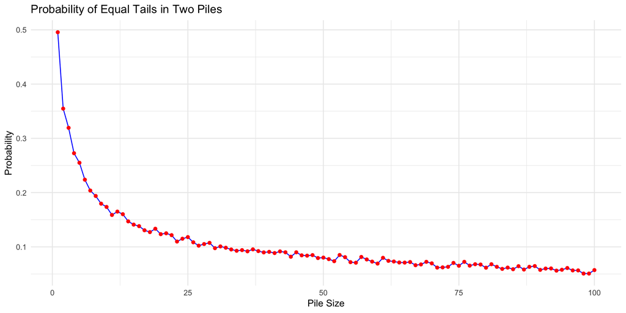

Probability of matching tails as a function of pile size

```r
library(ggplot2)

pile_size <- (1:100)

results_100 <- map_dbl(pile_size, coin_simulation, num_iterations = 5000)
results_df <- data.frame(pile_size = pile_size, probability = results_100)


ggplot(results_df, aes(x = pile_size, y = probability)) +
  geom_line(color = "blue") +
  geom_point(color = "red") +
  labs(
    title = "Probability of Equal Tails in Two Piles",
    x = "Pile Size",
    y = "Probability"
  ) +
  theme_minimal()
```

## How would the results change with varying pile sizes (2)?

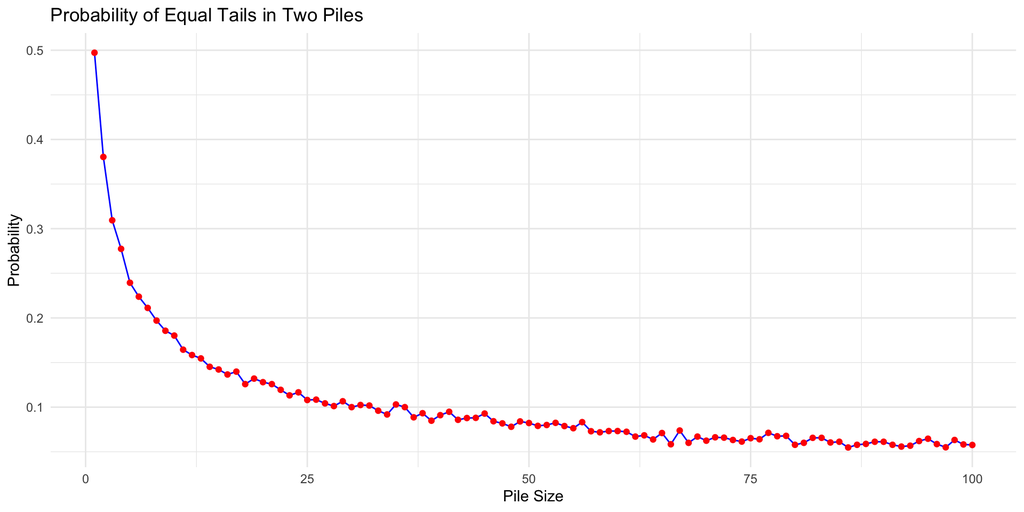

Probability of matching tails as a function of pile size

## Conclusions

- I’m not getting the job with this approach
- Reducing the size of the outcome space also reduces the probability of getting different outcomes over multiple trials
- Low number of trials essentially lowers the number of bins

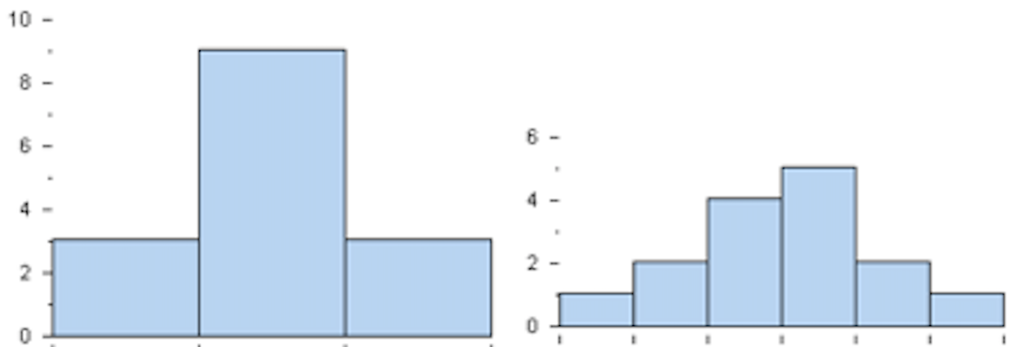

Normal Distribution

## Alternative Solution

Step 1: Throw 98 of the coins out the window.

Step 2: Flip the last two coins and hope you get the same result.